# Assignment - Week 07

Flurin Schindele

2026-04-20

```r
suppressPackageStartupMessages({
  library(dplyr)
  library(ggplot2)
  library(ggrepel)
  library(epiwraps)
  library(AnnotationHub)
  library(motifmatchr)
  library(MotifDb)
  library(universalmotif)
  library(sechm)
  library(Rsamtools)
  library(limma)
  library(betterChromVAR)
})
```

```
## See system.file("LICENSE", package="MotifDb") for use restrictions.
```

```r
ah <- AnnotationHub()
```

# 1. Signal around JUND motifs

We first load the ATAC-seq data from chromosome 19. As we want to look at the insertion sites of nucleosome-free fragments, and the centers of nucleosome-containing fragments, we will only load these two tracks.

```r
# we prepare the list of tracks
tracks <- list.files(path=".", recursive=TRUE, pattern="bw$")
names(tracks) <- gsub("\\.bw","",basename(tracks))
tracks1 <- tracks[grep("NF_cuts|mono_centers", tracks)]
```

```r
genome <- ah[["AH68356"]]
```

```
## loading from cache
```

```
## require("rtracklayer")
```

```r
# get the sequence for chr19:
chr19 <- import(genome)["19"]
```

Now we query for the motif of the JUND transcription factor and then perform motif matching to find the positions of the motif across chromosome 19.

```r
# get TF motif
motif <- MotifDb::query(MotifDb, c("JUND","Mus", "HOCOMOCO"))[[1]]
motif2 <- convert_motifs(motif, class="TFBSTools-PFMatrix")
```

```
## Note: motif [motif] has an empty nsites slot, using 100.
```

```r
# find motif matches across chr19
moi <- motifmatchr::matchMotifs(motif2, chr19, out="positions", p.cutoff=1e-5)[[1]]
# convert to GRanges
moi <- as(setNames(moi,names(chr19)), "GRanges")
```

Finally, we can plot the signal around the JUND motifs. In the mono_centers track, we do not see the two distinct peaks to the left and right of the motif which corresponded to the well-positioned nucleosomes flanking the CTCF motif. The NF_cuts track shows the insertion sites of the transposase in nucleosome-free fragments. We see peaks just to the left and right of the motif center but again not as strong as for CTCF. Generally, this is due to the fact that the bound TF protects the DNA from transposition, and therefore the cuts are enriched just outside of the motif. For TFs that bind more stably, the protection is stronger and the peaks in the NF_cuts track are more pronounced. This could suggest that JUND binding is less stable than CTCF binding.

```r
sm <- signal2Matrix(tracks1, moi, w=5, extend=250)
```

```
## Reading data/mono_centers.bw
```

```
## Reading data/NF_cuts.bw
```

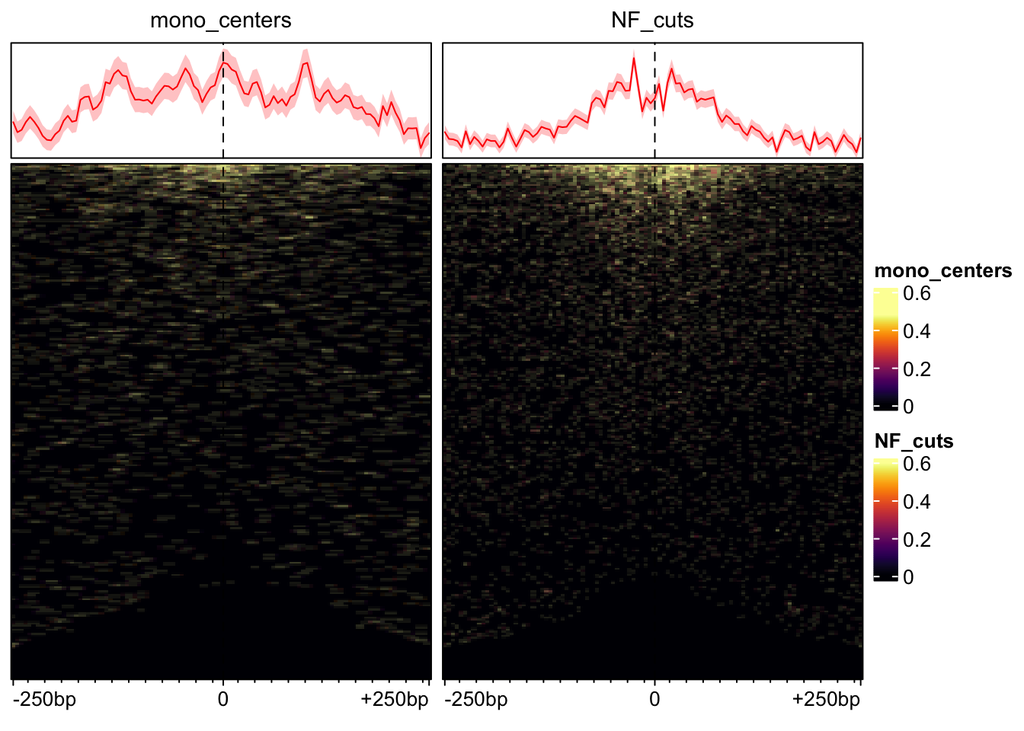

```r
# plot the signalsœ:
plotEnrichedHeatmaps(sm, trim=0.95, multiScale = TRUE, axis_name = "0", use_raster=TRUE)
```

When overlaying both signals in the same plot, we can’t really see any nucleosome centers to the left and right of the motif but the footprint in the insertion track is clearly visible.

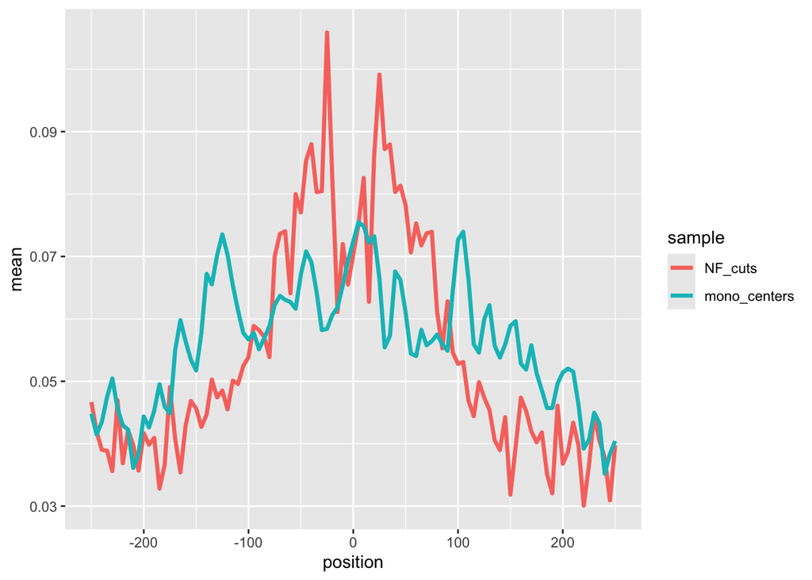

```r
d <- meltSignals(sm[,c("NF_cuts", "mono_centers")])
ggplot(d, aes(position, mean, colour=sample)) + geom_line(size=1.2)
```

# 2. Differential accessibility

Now we turn to the hippocampus data from stressed (forced swim stress) mice and we want to look at differentially accessible motifs between male and female mice.

```r
download.file("https://ethz-ins.org/content/mouse_mm38_hippocampus.peakCounts.SE.rds", "data/peakCounts.rds", mode="wb")
se <- readRDS("data/peakCounts.rds")

se <- GenomeInfoDb::keepStandardChromosomes(se, pruning.mode = "coarse")
seqlevelsStyle(se) <- "UCSC"
se <- betterChromVAR::addGCBias(se, genome=FaFile("../week06/data/mm10.fa"))
```

```r
motifs <- query(MotifDb, "HOCOMOCOv13")
motifs <- do.call(TFBSTools::PWMatrixList, convert_motifs(motifs, class="TFBSTools-PWMatrix"))
names(motifs) <- make.unique(sapply(motifs, \(x) gsub("\\..+","",x@name)))
```

For each peak in the `se` object, we find out which motifs match it, and then we compute the relative accessibility of each motif in each sample. `matches` contains a logical sparse matrix of dimensions (number of peaks) x (number of motifs), where each entry indicates whether the motif matches the peak or not.

```r
matches <- motifmatchr::matchMotifs(motifs, se, genome=FaFile("../week06/data/mm10.fa"))
matches
```

```
## class: RangedSummarizedExperiment
## dim: 20660 1358
## metadata(0):
## assays(1): motifMatches
## rownames: NULL
## rowData names(1): bias
## colnames(1358): LEUTX FBXL19 ... ZSCA1 ZSCA4
## colData names(1): name
```

```r
assay(matches)[1:10, 1:25]
```

```
## 10 x 25 sparse Matrix of class "lgCMatrix"
```

```
##   [[ suppressing 25 column names 'LEUTX', 'FBXL19', 'ZBED5' ... ]]
```

```
##
##  [1,] . . . . . . . . . . . . . . . . . . . . . . . . .
##  [2,] . . . . . . . . . . . | . . . . | . | . . . . . .
##  [3,] . . . . . . . . . . . . . . . . . . . . . . . . .
##  [4,] . . . . . . . . . . . . . . . . . . . . . . . . .
##  [5,] . . . . . . . . . . . . . . . . . . . . . . . . .
##  [6,] . . . . . . . . . . . . . . . . . . . . . . . . .
##  [7,] . . . . . . . . . . . . . . . . . . . . . . . . .
##  [8,] . . . . . . . . . . . . . . . | . . . . . . . . .
##  [9,] . . . . . . . . . . . . . . . . . . . . . . . . .
## [10,] . . . . . . . . . . . . . . . . . . . . . . . . .
```

`dev` is of shape (number of motifs) x (number of samples).

```r
dev <- betterChromVAR(se, matches)
dev
```

```
## class: SummarizedExperiment
## dim: 1358 12
## metadata(0):
## assays(2): deviations z
## rownames(1358): LEUTX FBXL19 ... ZSCA1 ZSCA4
## rowData names(6): name N ... var.pval var.adjPval
## colnames(12): Control_female_GSM6041841.bam
##   Control_female_GSM6041842.bam ... FSS_male_GSM6041857.bam
##   FSS_male_GSM6041858.bam
## colData names(1): depth
```

```r
assay(dev)[1:5, c(1, 12)]
```

```
##        Control_female_GSM6041841.bam FSS_male_GSM6041858.bam
## LEUTX                   0.0001189404            0.0005326258
## FBXL19                 -0.0007860278            0.0008799841
## ZBED5                   0.0004292836           -0.0004459600
## ZFAT                   -0.0007059516            0.0004365272
## ZSCAN2                  0.0003971582           -0.0004941744
```

We can then fit a model to find motifs that are differentially accessible between sex, while controlling for the stressed/unstressed condition.

```r
dev$sex <- ifelse(grepl("female", colnames(dev)), "Female", "Male")
dev$condition <- ifelse(grepl("Control", colnames(dev)), "Control", "Stressed")
design <- model.matrix(~sex + condition, data=as.data.frame(colData(dev)))
fit <- eBayes(lmFit(assay(dev, "z"), design))
res <- as.data.frame(topTable(fit, number = Inf))
```

```
## Removing intercept from test coefficients
```

```r
res$motif <- row.names(res)
```

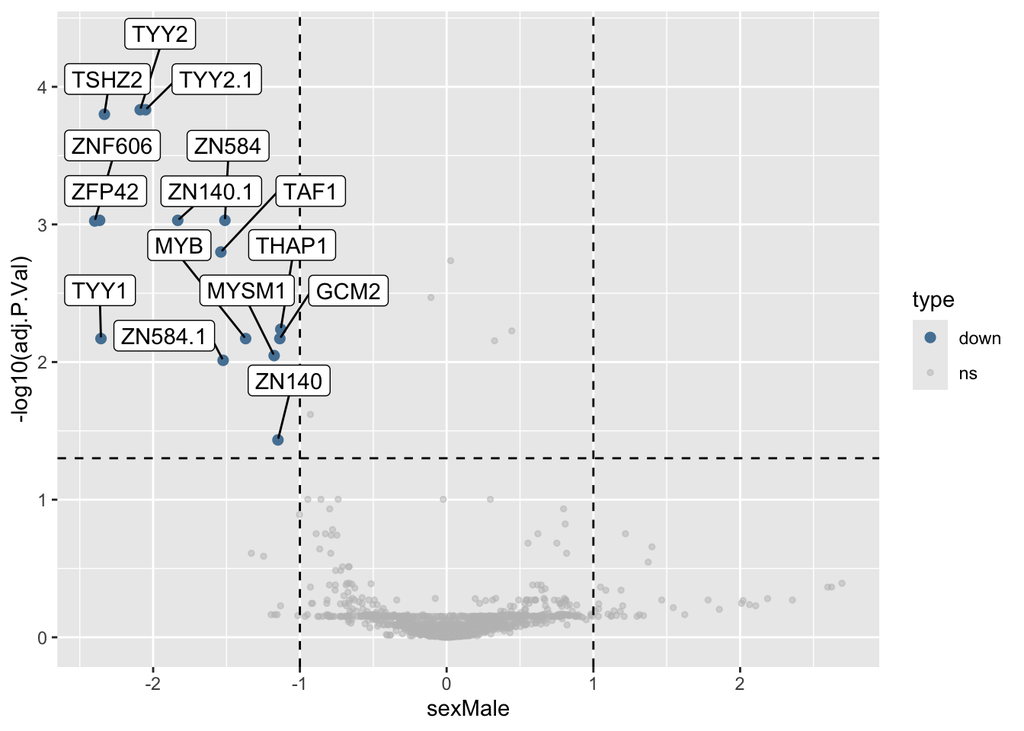

```r
colors <- c("up" = "#C04F15", "down" = "#5682A3", "ns" = "grey")
sizes <- c("up" = 2, "down" = 2, "ns" = 1)
alphas <- c("up" = 1, "down" = 1, "ns" = 0.5)

res <- res %>%
  mutate(type = case_when(
    sexMale >= 1 & adj.P.Val <= 0.05 ~ "up",
    sexMale <= -1 & adj.P.Val <= 0.05 ~ "down",
    TRUE ~ "ns"
    )
)

res$type <- factor(res$type, levels=c("up", "down", "ns"))
ggplot(data = res,
       aes(x = sexMale,
           y = -log10(adj.P.Val))) +
  geom_point(aes(color = type,
                 size = type,
                 alpha = type)) +
  geom_hline(yintercept = -log10(0.05),
             linetype = "dashed") +
  geom_vline(xintercept = c(log2(0.5), log2(2)),
             linetype = "dashed") +
  geom_label_repel(data = res[res$type == "down" | res$type == "up", ], # Add labels last to appear as the top layer
                   aes(label = res$motif[res$type == "down" | res$type == "up"]),
                   force = 2,
                   nudge_y = 0.5) +
  scale_colour_manual(values = colors) +
  scale_size_manual(values = sizes) +
  scale_alpha_manual(values = alphas)
```

We see that multiple motifs are less accessible in male mice compared to female mice.

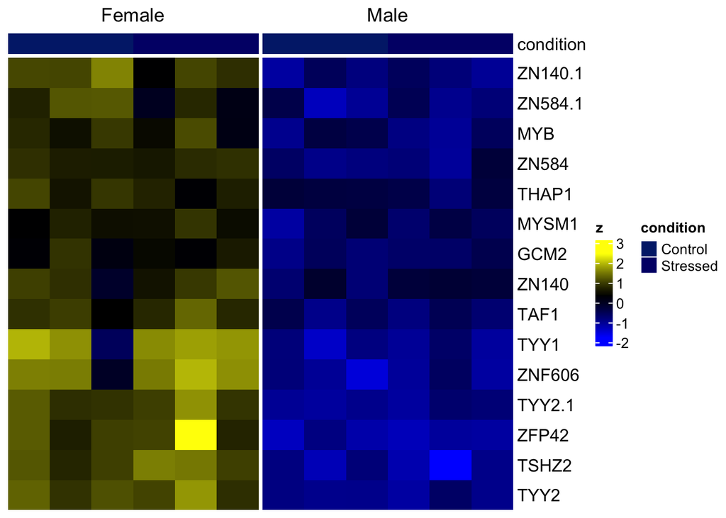

```r
sechm(dev, row.names(res[res$type != "ns",]), gaps_at="sex", assayName = "z")
```

## Comparing stressed vs unstressed mice

When we plot the same data but comparing stressed vs unstressed mice, we see that there are four motifs enriched in stressed mice.

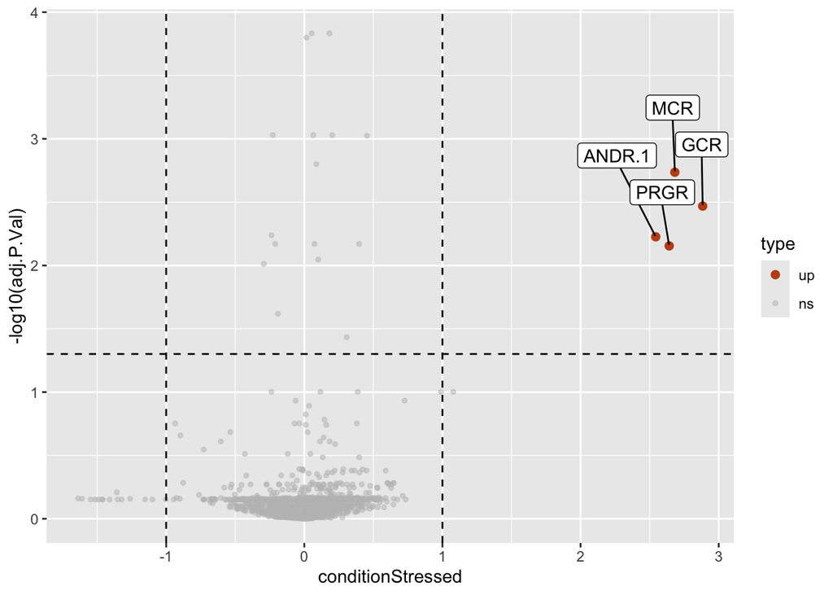

```r
colors <- c("up" = "#C04F15", "down" = "#5682A3", "ns" = "grey")
sizes <- c("up" = 2, "down" = 2, "ns" = 1)
alphas <- c("up" = 1, "down" = 1, "ns" = 0.5)

res <- res %>%
  mutate(type = case_when(
    conditionStressed >= 1 & adj.P.Val <= 0.05 ~ "up",
    conditionStressed <= -1 & adj.P.Val <= 0.05 ~ "down",
    TRUE ~ "ns"
    )
)

res$type <- factor(res$type, levels=c("up", "down", "ns"))
ggplot(data = res,
       aes(x = conditionStressed,
           y = -log10(adj.P.Val))) +
  geom_point(aes(color = type,
                 size = type,
                 alpha = type)) +
  geom_hline(yintercept = -log10(0.05),
             linetype = "dashed") +
  geom_vline(xintercept = c(log2(0.5), log2(2)),
             linetype = "dashed") +
  geom_label_repel(data = res[res$type == "down" | res$type == "up", ], # Add labels last to appear as the top layer
                   aes(label = res$motif[res$type == "down" | res$type == "up"]),
                   force = 2,
                   nudge_y = 0.5) +
  scale_colour_manual(values = colors) +
  scale_size_manual(values = sizes) +
  scale_alpha_manual(values = alphas)
```

The GCR motif being enriched makes sense biologically, as it is a motif for the glucocorticoid receptor which is activated in response to stress. The other motifs are similar to the GCR motif, and therefore likely represent the same underlying signal

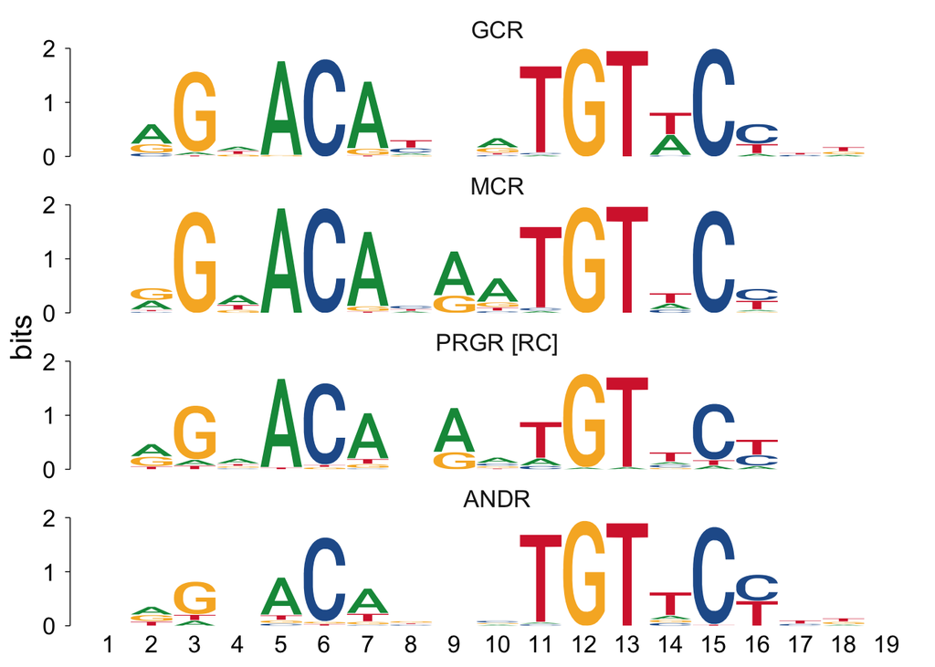

```r
view_motifs(motifs[c("GCR", "MCR", "PRGR", "ANDR.1")])
```